# Project_Full_Code_Notebook_EasyVisa

```
Counts (with row/column totals):
case_status         Certified  Denied    All
has_job_experience
N                        5994    4684  10678
Y                       11024    3778  14802
All                     17018    8462  25480
------------------------------------------------------------------------------------------------------------------------
```

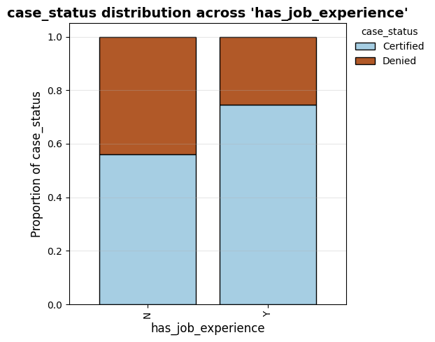

```
(<Figure size 600x500 with 1 Axes>,
 <Axes: title={'center': "case_status distribution across 'has_job_experience'"}, xlabel='has_job_experience', ylabel='Proportion of case_status'>)
```

```python
# Has Job Experience  vs. Case Status
stacked_barplot(data, 'has_job_experience', 'case_status')
```

```
Counts (with row/column totals):
case_status            Certified  Denied    All
requires_job_training
N                          15012    7513  22525
Y                           2006     949   2955
All                        17018    8462  25480
------------------------------------------------------------------------------------------------------------------------
```

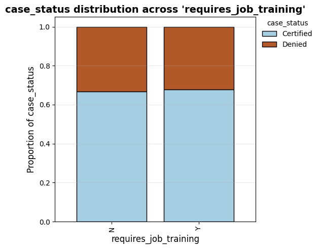

```
(<Figure size 600x500 with 1 Axes>,
 <Axes: title={'center': "case_status distribution across 'requires_job_training'"}, xlabel='requires_job_training', ylabel='Proportion of case_status'>)
```

```python
# Requires Job Training  vs. Case Status
stacked_barplot(data, 'requires_job_training', 'case_status')
```

- The stacked bar plot shows that approval proportions for applicants who require job training and those who do not are very similar.

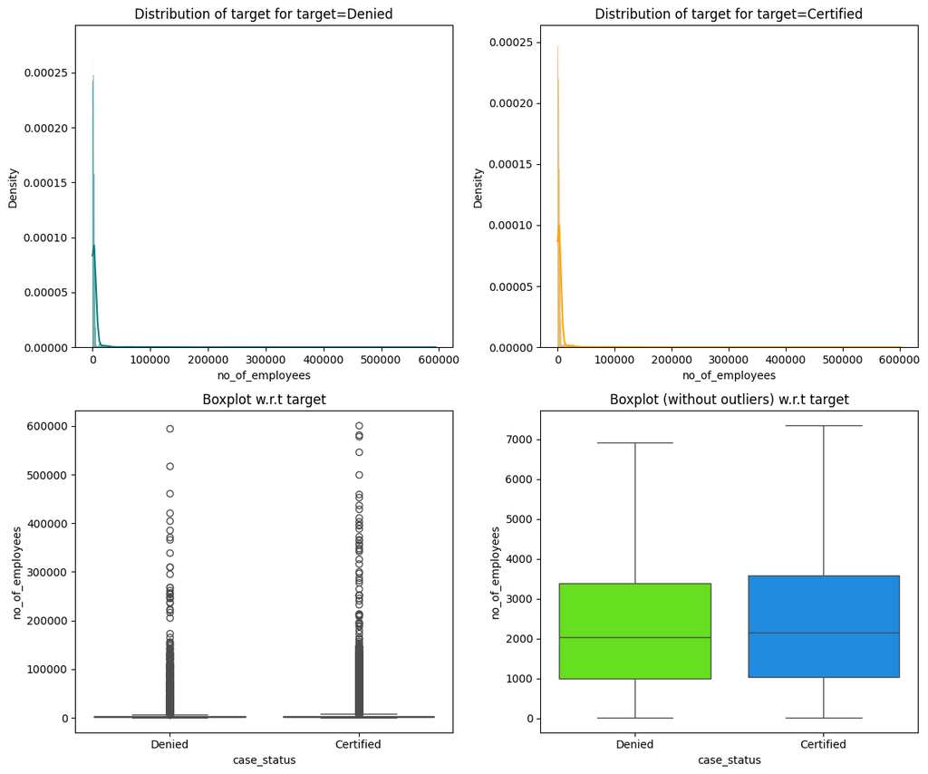

```python
# Number of Employees  vs. Case Status
distribution_plot_wrt_target(data, "no_of_employees", "case_status")
```

- The distribution of `no_of_employees` is highly right-skewed for both outcomes (Denied and Certified), with many extreme outliers, which is why the histograms look heavily concentrated near the lower end. When comparing groups using the boxplots without outliers, the Certified cases show a slightly higher median and upper spread than the Denied cases, suggesting that applications from larger companies tend to have somewhat higher approval likelihood. However, the overlap between the two distributions remains substantial.

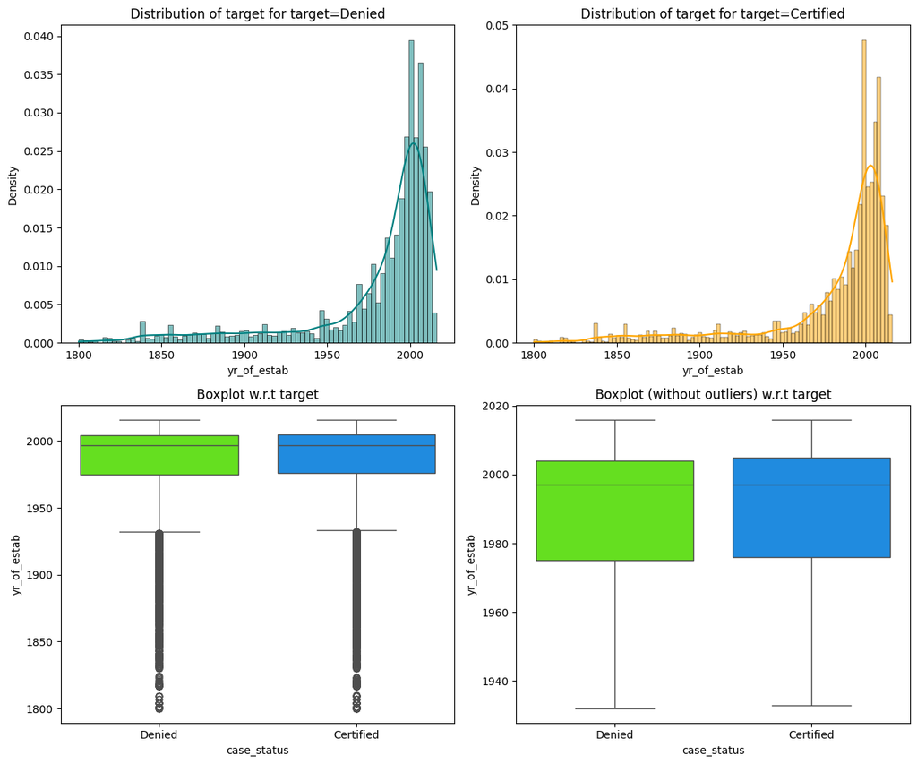

```python
# Year of Establishment vs. Case Status
distribution_plot_wrt_target(data, "yr_of_estab", "case_status")
```

- The distributions of `yr_of_estab` for Denied and Certified cases are quite similar, with both groups heavily concentrated in the late 1990s to early 2000s. The boxplots (especially without outliers) show that the medians and interquartile ranges overlap strongly, indicating that establishment year alone does not sharply separate approvals from denials. There is a long tail of very old establishment years in both classes, appearing as outliers.